# Reproducible Research - Course Project 2

echf

11/8/2021

## Exploring the U.S. National Oceanic and Atmospheric Administration’s (NOAA) storm database - Health and Economic Impacts

#### Introduction

##### Storms and other severe weather events can cause both public health and economic problems for communities and

##### municipalities. Many severe events can result in fatalities, injuries, and property damage, and preventing such outcomes to

##### the extent possible is a key concern.

##### This project involves exploring the U.S. National Oceanic and Atmospheric Administration’s (NOAA) storm database.

##### This database tracks characteristics of major storms and weather events in the United States, including when and where they

##### occur, as well as estimates of any fatalities, injuries, and property damage.

#### Data

##### The data for this assignment come in the form of a comma-separated-value file compressed via the bzip2 algorithm to reduce

##### its size. You can download the file from the course web site: Storm Data 47Mb

https://d396qusza40orc.cloudfront.net/repdata%2Fdata%2FStormData.csv.bz2

##### National Weather Service Storm Data Documentation

```
https://d396qusza40orc.cloudfront.net/repdata%2Fpeer2_doc%2Fpd01016005curr.pdf
```

##### National Climatic Data Center Storm Events FAQ

```
   https://d396qusza40orc.cloudfront.net/repdata%2Fpeer2_doc%2FNCDC%20Storm%20Events-FAQ%20Page.pdf
```

### Population health:

- Number of injuries.
- Number of deaths.

### Economic impact:

- Total cost of property damage.
- Total cost of crop damage.

### Data Processing

#### Load Libraries and prepare the R environment

```r
options(scipen = 1)  # Turn off scientific notations for numbers
library(R.utils)
```

```r
library(ggplot2)
library(plyr)
require(gridExtra)
library(dplyr)
```

### Download the data

```r
url <- "https://d396qusza40orc.cloudfront.net/repdata%2Fdata%2FStormData.csv.bz2"
download.file(url, "StormData.csv.bz2")
library(R.utils)
bunzip2("StormData.csv.bz2", "StormData.csv", overwrite=T, remove=F)
df_storm <- read.csv("StormData.csv")
names(df_storm)
```

```
##  [1] "STATE__"    "BGN_DATE"   "BGN_TIME"   "TIME_ZONE"  "COUNTY"
##  [6] "COUNTYNAME" "STATE"      "EVTYPE"     "BGN_RANGE"  "BGN_AZI"
## [11] "BGN_LOCATI" "END_DATE"   "END_TIME"   "COUNTY_END" "COUNTYENDN"
## [16] "END_RANGE"  "END_AZI"    "END_LOCATI" "LENGTH"     "WIDTH"
## [21] "F"          "MAG"        "FATALITIES" "INJURIES"   "PROPDMG"
## [26] "PROPDMGEXP" "CROPDMG"    "CROPDMGEXP" "WFO"        "STATEOFFIC"
## [31] "ZONENAMES"  "LATITUDE"   "LONGITUDE"  "LATITUDE_E" "LONGITUDE_"
## [36] "REMARKS"    "REFNUM"
```

```r
str(df_storm)
```

```
## 'data.frame':    902297 obs. of  37 variables:
##  $ STATE__   : num  1 1 1 1 1 1 1 1 1 1 ...
##  $ BGN_DATE  : chr  "4/18/1950 0:00:00" "4/18/1950 0:00:00" "2/20/1951 0:00:00" "6/8/1951 0:00:00" ...
##  $ BGN_TIME  : chr  "0130" "0145" "1600" "0900" ...
##  $ TIME_ZONE : chr  "CST" "CST" "CST" "CST" ...
##  $ COUNTY    : num  97 3 57 89 43 77 9 123 125 57 ...
##  $ COUNTYNAME: chr  "MOBILE" "BALDWIN" "FAYETTE" "MADISON" ...
##  $ STATE     : chr  "AL" "AL" "AL" "AL" ...
##  $ EVTYPE    : chr  "TORNADO" "TORNADO" "TORNADO" "TORNADO" ...
##  $ BGN_RANGE : num  0 0 0 0 0 0 0 0 0 0 ...
##  $ BGN_AZI   : chr  "" "" "" "" ...
##  $ BGN_LOCATI: chr  "" "" "" "" ...
##  $ END_DATE  : chr  "" "" "" "" ...
##  $ END_TIME  : chr  "" "" "" "" ...
##  $ COUNTY_END: num  0 0 0 0 0 0 0 0 0 0 ...
```

[output cut: 23 more lines]

#### Economic variables:

###### PROPDMG: approx. property damags

###### PROPDMGEXP: the units for property damage value

###### CROPDMG: approx. crop damages

###### CROPDMGEXP: the units for crop damage value

#### Events - target variable:

###### EVTYPE: weather event (Tornados, Wind, Snow, Flood, etc..)

###### Extract variables of interest from original data set:

#### Health variables:

- INJURIES: approx. number of injuries
- FATALITIES: approx. number of deaths
- propdamage: property damage
- cropdamage: Crop damage

```r
head(df_storm,10)
```

```
##    STATE__           BGN_DATE BGN_TIME TIME_ZONE COUNTY COUNTYNAME STATE
## 1        1  4/18/1950 0:00:00     0130       CST     97     MOBILE    AL
## 2        1  4/18/1950 0:00:00     0145       CST      3    BALDWIN    AL
## 3        1  2/20/1951 0:00:00     1600       CST     57    FAYETTE    AL
## 4        1   6/8/1951 0:00:00     0900       CST     89    MADISON    AL
## 5        1 11/15/1951 0:00:00     1500       CST     43    CULLMAN    AL
## 6        1 11/15/1951 0:00:00     2000       CST     77 LAUDERDALE    AL
## 7        1 11/16/1951 0:00:00     0100       CST      9     BLOUNT    AL
## 8        1  1/22/1952 0:00:00     0900       CST    123 TALLAPOOSA    AL
## 9        1  2/13/1952 0:00:00     2000       CST    125 TUSCALOOSA    AL
## 10       1  2/13/1952 0:00:00     2000       CST     57    FAYETTE    AL
##     EVTYPE BGN_RANGE BGN_AZI BGN_LOCATI END_DATE END_TIME COUNTY_END COUNTYENDN
## 1  TORNADO         0                                               0         NA
## 2  TORNADO         0                                               0         NA
## 3  TORNADO         0                                               0         NA
```

[output cut: 40 more lines]

#### Extracting variables of interest for analysis of weather impact on health and economy

#### From a list of variables in storm data, these are columns of interest:

```r
df_storm2 <- df_storm %>%
  select(c("EVTYPE","FATALITIES","INJURIES","PROPDMG","PROPDMGEXP","CROPDMG","CROPDMGEXP")) %>%
  rename_all(tolower)
str(df_storm2)
```

```
## 'data.frame':    902297 obs. of  7 variables:
##  $ evtype    : chr  "TORNADO" "TORNADO" "TORNADO" "TORNADO" ...
##  $ fatalities: num  0 0 0 0 0 0 0 0 1 0 ...
##  $ injuries  : num  15 0 2 2 2 6 1 0 14 0 ...
##  $ propdmg   : num  25 2.5 25 2.5 2.5 2.5 2.5 2.5 25 25 ...
##  $ propdmgexp: chr  "K" "K" "K" "K" ...
##  $ cropdmg   : num  0 0 0 0 0 0 0 0 0 0 ...
##  $ cropdmgexp: chr  "" "" "" "" ...
```

##### Property damage estimates were entered as actual dollar amounts

```r
sort(table(df_storm2$propdmgexp), decreasing = TRUE)[1:10]
```

```
##
##             K      M      0      B      5      1      2      ?      m
## 465934 424665  11330    216     40     28     25     13      8      7
```

```r
sort(table(df_storm2$cropdmgexp), decreasing = TRUE)[1:10]
```

```
##
##             K      M      k      0      B      ?      2      m   <NA>
## 618413 281832   1994     21     19      9      7      1      1
```

#### Transform EVTYPE to all caps

#### This will improve consistency across categories

```r
df_storm2$evtype <- as.character(df_storm2$evtype)
df_storm2$evtype <- toupper(df_storm2$evtype)
```

#### Calculate property damage value

#### Need to recode the exponent variable so we can multiply it by the propdmg value.

```r
df_storm2$propdmgexp <- toupper(df_storm2$propdmgexp)
df_storm2 <- mutate(df_storm2, propdmgexp2 = recode(propdmgexp,
                                             "1" = 10,
                                             "2" = 100,
                                             "3" = 1000,
                                             "4" = 10000,
                                             "5" = 100000,
                                             "6" = 1000000,
                                             "7" = 10000000,
                                             "8" = 100000000,
                                             "H" = 100,
                                             "K" = 1000,
                                             "M" = 1000000,
                                             "B" = 1000000000,
                                             .default = 1))
df_storm2 <- mutate(df_storm2, propdmgvalue = propdmg*propdmgexp2)
```

### Calculate values

#### Calculate crop damage value

#### Need to recode the exponent variable so we can multiply it by the cropdmg value.

```r
df_storm2$cropdmgexp <- toupper(df_storm2$cropdmgexp)
df_storm2 <- mutate(df_storm2, cropdmgexp2 = recode(cropdmgexp,
                                                  "1" = 10,
                                                  "2" = 100,
                                                  "3" = 1000,
                                                  "4" = 10000,
                                                  "5" = 100000,
                                                  "6" = 1000000,
                                                  "7" = 10000000,
                                                  "8" = 100000000,
                                                  "H" = 100,
                                                  "K" = 1000,
                                                  "M" = 1000000,
                                                  "B" = 1000000000,
                                                 .default = 1))
df_storm2 <- mutate(df_storm2, cropdmgvalue = cropdmg*cropdmgexp2)
head(df_storm2,10)
```

```
##     evtype fatalities injuries propdmg propdmgexp cropdmg cropdmgexp
## 1  TORNADO          0       15    25.0          K       0
## 2  TORNADO          0        0     2.5          K       0
## 3  TORNADO          0        2    25.0          K       0
## 4  TORNADO          0        2     2.5          K       0
## 5  TORNADO          0        2     2.5          K       0
## 6  TORNADO          0        6     2.5          K       0
## 7  TORNADO          0        1     2.5          K       0
## 8  TORNADO          0        0     2.5          K       0
## 9  TORNADO          1       14    25.0          K       0
## 10 TORNADO          0        0    25.0          K       0
##    propdmgexp2 propdmgvalue cropdmgexp2 cropdmgvalue
## 1         1000        25000           1            0
## 2         1000         2500           1            0
## 3         1000        25000           1            0
## 4         1000         2500           1            0
## 5         1000         2500           1            0
## 6         1000         2500           1            0
## 7         1000         2500           1            0
## 8         1000         2500           1            0
## 9         1000        25000           1            0
## 10        1000        25000           1            0
```

#### Injury data

```r
injuries <- aggregate(injuries~evtype, data = df_storm2, FUN = sum)
injuries <- injuries[order(injuries$injuries, decreasing = TRUE), ]
injuries <- injuries[1:10, ]
injuries
```

```
##                evtype injuries
## 758           TORNADO    91346
## 779         TSTM WIND     6957
## 154             FLOOD     6789
## 116    EXCESSIVE HEAT     6525
## 418         LIGHTNING     5230
## 243              HEAT     2100
## 387         ICE STORM     1975
## 138       FLASH FLOOD     1777
## 685 THUNDERSTORM WIND     1488
## 212              HAIL     1361
```

#### Fatality data

```r
fatalities <- aggregate(fatalities~evtype, data = df_storm2, FUN = sum) #aggregate fatalities by event type
fatalities <- fatalities[order(fatalities$fatalities, decreasing = TRUE), ] #order number of fatalities in decending order
fatalities <- fatalities[1:10, ] #take the top 5
fatalities
```

```
##             evtype fatalities
## 758        TORNADO       5633
## 116 EXCESSIVE HEAT       1903
## 138    FLASH FLOOD        978
## 243           HEAT        937
## 418      LIGHTNING        816
## 779      TSTM WIND        504
## 154          FLOOD        470
## 524    RIP CURRENT        368
## 320      HIGH WIND        248
## 19       AVALANCHE        224
```

#### Property damage data

```r
propdamage <- aggregate(propdmgvalue~evtype, data = df_storm2, FUN = sum)
propdamage <- propdamage[order(propdamage$propdmgvalue, decreasing = TRUE), ]
propdamage <- propdamage[1:10, ]
propdamage
```

```
##                evtype propdmgvalue
## 154             FLOOD 144657709807
## 372 HURRICANE/TYPHOON  69305840000
## 758           TORNADO  56947380677
## 599       STORM SURGE  43323536000
## 138       FLASH FLOOD  16822673979
## 212              HAIL  15735267513
## 363         HURRICANE  11868319010
## 772    TROPICAL STORM   7703890550
## 888      WINTER STORM   6688497251
## 320         HIGH WIND   5270046295
```

#### Crop damage data

```r
cropdamage <- aggregate(cropdmgvalue~evtype, data = df_storm2, FUN = sum)
cropdamage <- cropdamage[order(cropdamage$cropdmgvalue, decreasing = TRUE), ]
cropdamage <- cropdamage[1:10, ]
cropdamage
```

```
##                evtype cropdmgvalue
## 84            DROUGHT  13972566000
## 154             FLOOD   5661968450
## 529       RIVER FLOOD   5029459000
## 387         ICE STORM   5022113500
## 212              HAIL   3025954473
## 363         HURRICANE   2741910000
## 372 HURRICANE/TYPHOON   2607872800
## 138       FLASH FLOOD   1421317100
## 125      EXTREME COLD   1312973000
## 187      FROST/FREEZE   1094186000
```

## The events that cause the most damage in relation to meteorological events in the United States of America are shown below.

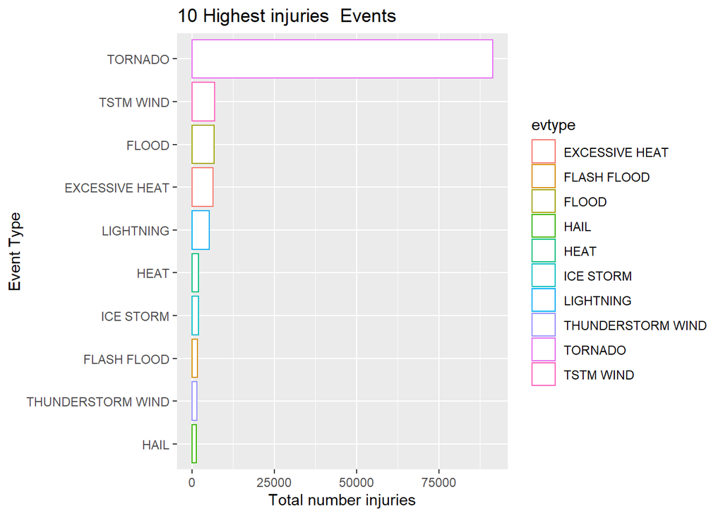

```r
injuriesPlot <- ggplot(data=injuries, aes(x=reorder(evtype, injuries), y=injuries, color=evtype)) +
  geom_bar(stat="identity",fill="white") +
  xlab("Event Type") +
  ylab("Total number injuries") +
  ggtitle("10 Highest injuries  Events") +
  scale_fill_manual(values=c("#999999", "#E69F00", "#56B4E9"))

injuriesPlot + coord_flip()
```

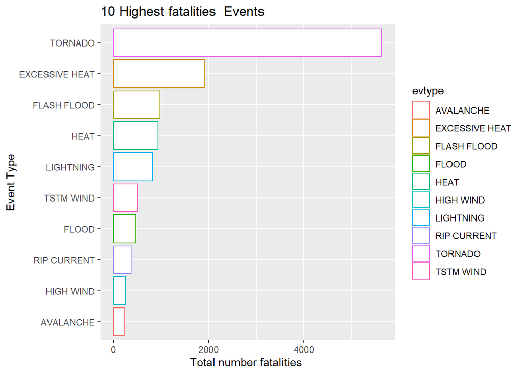

```r
fatalitiesPlot <- ggplot(data=fatalities, aes(x=reorder(evtype, fatalities), y=fatalities, color=evtype)) +
  geom_bar(stat="identity",fill="white") +
  xlab("Event Type") +
  ylab("Total number fatalities ") +
  ggtitle("10 Highest fatalities  Events") +
  scale_fill_manual(values=c("#999999", "#E69F00", "#56B4E9"))

fatalitiesPlot + coord_flip()
```

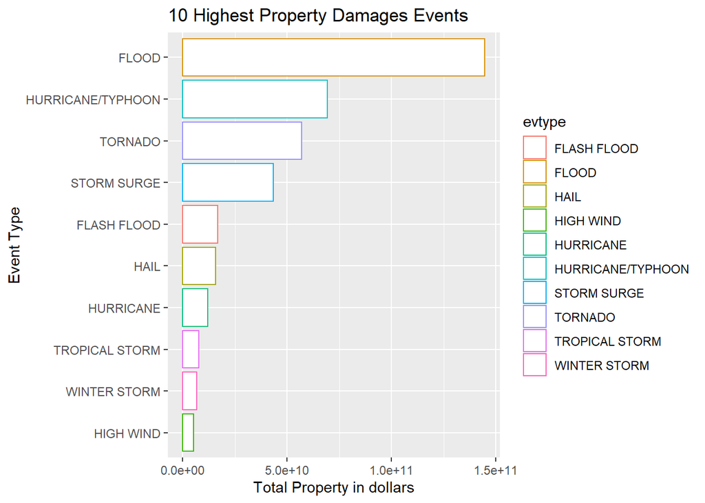

```r
propdamagePlot <- ggplot(data=propdamage, aes(x=reorder(evtype, propdmgvalue), y=propdmgvalue, color=evtype)) +
  geom_bar(stat="identity",fill="white") +
  xlab("Event Type") +
  ylab("Total Property in dollars") +
  ggtitle("10 Highest Property Damages Events") +
  scale_fill_manual(values=c("#999999", "#E69F00", "#56B4E9"))

propdamagePlot + coord_flip()
```

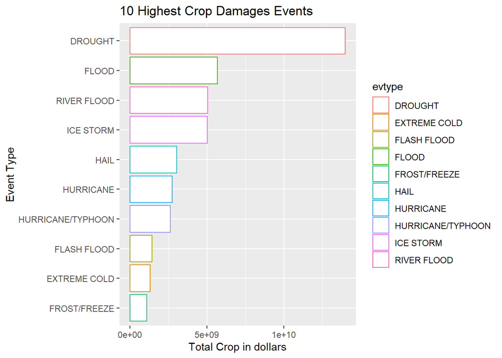

```r
cropdamagePlot <- ggplot(data=cropdamage, aes(x=reorder(evtype, cropdmgvalue), y=cropdmgvalue, color=evtype)) +
  geom_bar(stat="identity",fill="white") +
  xlab("Event Type") +
  ylab("Total Crop in dollars") +
  ggtitle("10 Highest Crop Damages Events") +
  scale_fill_manual(values=c("#999999", "#E69F00", "#56B4E9"))

cropdamagePlot + coord_flip()
```